# Cars4U Case Study - Connie Xavier

## Data Consistency - Missing Value Treatment

```python
# check total number of missing values
df3 = df2.copy()
df3.isnull().sum()[df3.isnull().sum() > 0]
```

```
Mileage      1
Engine      36
Power      140
Seats       42
dtype: int64
```

```python
# fill in missing values based on other cars with the same name
for item in ["Mileage", "Seats", "Engine", "Power"]:
    df3[item].fillna(value=df3.groupby("Name")[item].transform(np.median), inplace=True)
df3.isnull().sum()[df3.isnull().sum() > 0]
```

```
Mileage      1
Engine      31
Power      111
Seats       36
dtype: int64
```

```python
# There are only few missing values for Mileage, so we will drop it
df3.dropna(subset="Mileage", axis=0, inplace=True)
df3.isnull().sum()[df3.isnull().sum() > 0]
```

```
Engine     31
Power     110
Seats      36
dtype: int64
```

```python
# Since Power and Engine are correlated, fill in missing values of Power based on Engine
df3.Power.fillna(
    value=df3.groupby("Engine")["Power"].transform(np.median), inplace=True
)
df3.isnull().sum()[df3.isnull().sum() > 0]
```

```
Engine    31
Power     39
Seats     36
dtype: int64
```

```python
# check how many missing rows
print((1 - (df3.dropna().shape[0] / df3.shape[0])) * 100, "%")
```

```
0.7350484463748752 %
```

```python
# since only a small % of data, we will drop the rows
df3.dropna(axis=0, subset=["Engine", "Power", "Seats"], inplace=True)
df3.isnull().sum()[df3.isnull().sum() > 0]
```

```
Series([], dtype: int64)
```

```
Mileage
```

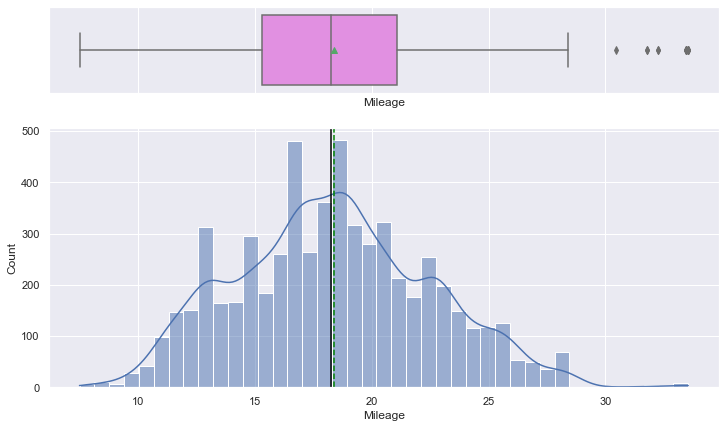

```
median before =  18.2 median after =  18.275
mean before =  18.347575183691237 mean after =  18.365125796542866
Engine
```

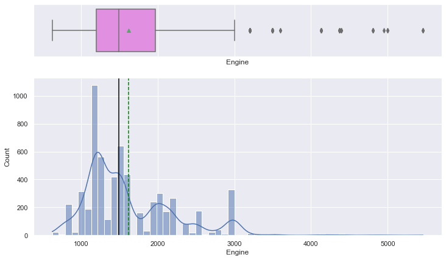

```
median before =  1493.0 median after =  1493.0
mean before =  1617.6503108721224 mean after =  1616.8115112756648
Power
```

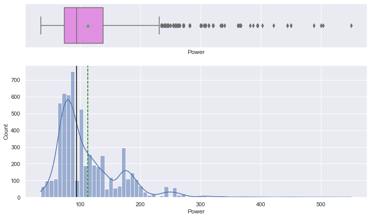

```
median before =  94.0 median after =  93.7
mean before =  113.05116983068147 mean after =  112.50210198586257
```

```python
# plot distributions of all variables you changed and compare medians before and after missing value treatment
for item in ["Mileage", "Engine", "Power"]:
    print(item)
    histogram_boxplot(df3, item)
    plt.show()
    print("median before = ", df2[item].median(), "median after = ", df3[item].median())
    print("mean before = ", df2[item].mean(), "mean after = ", df3[item].mean())
    print("*" * 50)
```

All distributions stayed approximately the same after missing value treatment.

|  | Year | Kilometers_Driven | Mileage | Engine | Power | Seats | New_Price | Price |
| --- | --- | --- | --- | --- | --- | --- | --- | --- |
| Year | 0.000000 | -0.000449 | -0.001825 | -0.000386 | 0.015000 | -0.001780 | 0.002430 | 0.001943 |
| Kilometers_Driven | -0.000449 | 0.000000 | 0.000923 | 0.000916 | -0.005499 | 0.000257 | 0.001350 | 0.000829 |
| Mileage | -0.001825 | 0.000923 | 0.000000 | 0.000996 | 0.003389 | -0.004804 | -0.000444 | -0.000113 |
| Engine | -0.000386 | 0.000916 | 0.000996 | 0.000000 | 0.000162 | 0.006193 | -0.000853 | -0.000360 |
| Power | 0.015000 | -0.005499 | 0.003389 | 0.000162 | 0.000000 | 0.002670 | 0.000727 | 0.000561 |
| Seats | -0.001780 | 0.000257 | -0.004804 | 0.006193 | 0.002670 | 0.000000 | 0.006953 | 0.004280 |
| New_Price | 0.002430 | 0.001350 | -0.000444 | -0.000853 | 0.000727 | 0.006953 | 0.000000 | 0.000106 |
| Price | 0.001943 | 0.000829 | -0.000113 | -0.000360 | 0.000561 | 0.004280 | 0.000106 | 0.000000 |

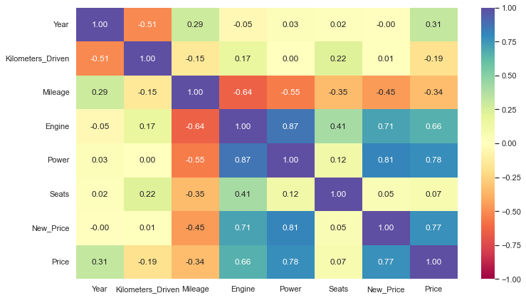

```python
# check how correlations changed
corr_cols = df3.dtypes[(df3.dtypes == np.number) | (df3.dtypes == np.int64)].index
plt.figure(figsize=(12, 7))
sns.heatmap(
    df3[corr_cols].corr(), annot=True, vmin=-1, vmax=1, fmt=".2f", cmap="Spectral"
)
df3[corr_cols].corr() - df2[corr_cols].corr()
```

There was barely any change to correlations.

### Feature Engineering - Transformations

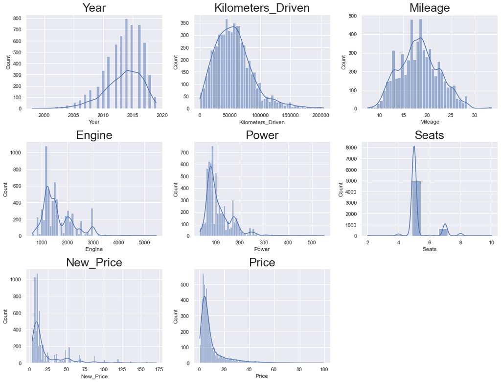

```python
# let's plot a histogram of all numerical columns
dist_cols = [item for item in df3.select_dtypes(include=[np.number, np.int64]).columns]
plt.figure(figsize=(15, 45))

for i in range(len(corr_cols)):
    plt.subplot(12, 3, i + 1)
    sns.histplot(data=df3, x=dist_cols[i], kde=True)
    plt.tight_layout()
    plt.title(dist_cols[i], fontsize=25)
```

```python
# check there are no 0 values so log transformation can be applied
df3.min()
```

```
Year                 1998.00
Kilometers_Driven     171.00
Mileage                 7.50
Engine                624.00
Power                  34.20
Seats                   2.00
New_Price               3.91
Price                   0.44
dtype: float64
```

```python
# creating a copy of the dataframe
df4 = df3.copy()
# the min value of price is close to 0, so we will use INR for units instead
df4.Price = df4.Price * 100000
# also dropping the Mileage column as it is almost normally distributed and the Year column since it is left not right skewed
dist_cols.remove("Mileage")
dist_cols.remove("Year")
dist_cols
```

```
['Kilometers_Driven', 'Engine', 'Power', 'Seats', 'New_Price', 'Price']
```

```python
# using log transforms on right-skewed columns
for col in dist_cols:
    df4[col + "_log"] = np.log(df4[col])

# dropping the original columns
df4.drop(dist_cols, axis=1, inplace=True)
df4.columns
```

```
Index(['Name', 'Location', 'Year', 'Fuel_Type', 'Transmission', 'Owner_Type',
       'Mileage', 'Make', 'Kilometers_Driven_log', 'Engine_log', 'Power_log',
       'Seats_log', 'New_Price_log', 'Price_log'],
      dtype='object')
```

```python
# standardize continuous features that are normally distributed
from sklearn.preprocessing import StandardScaler

std_scaler = StandardScaler()

std_cols = ["Year", "Mileage"]
for col in std_cols:
    df4[col + "_std"] = std_scaler.fit_transform(df4[[col]])

df4.drop(std_cols, axis=1, inplace=True)
```

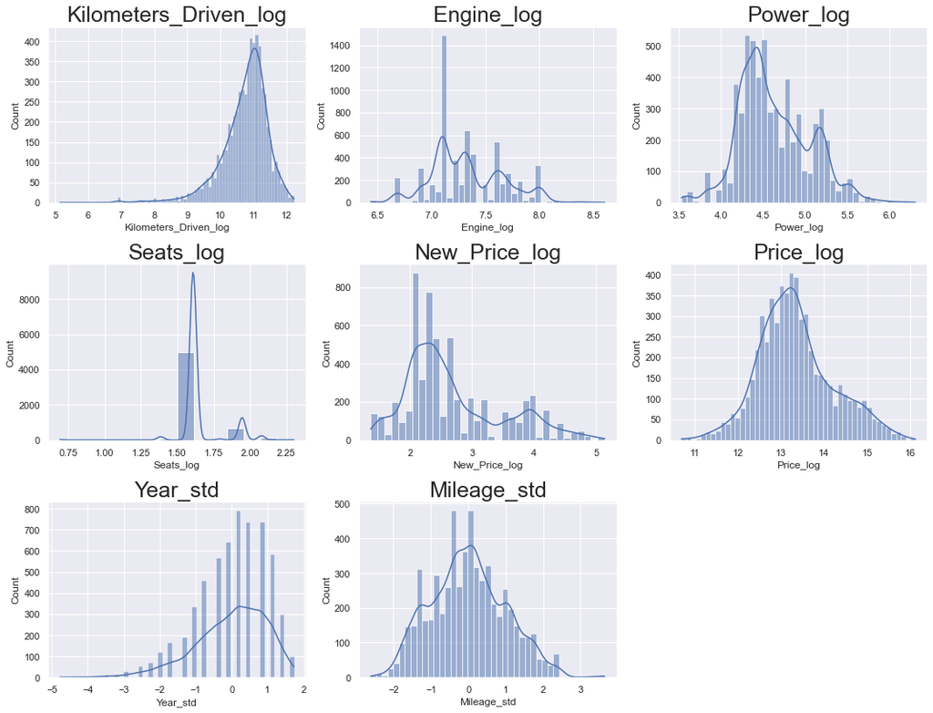

```python
# check for skewnewss after log transformation by plotting histograms
dist_cols = [item for item in df4.select_dtypes(include=[np.number, np.int64]).columns]
plt.figure(figsize=(15, 45))
for i in range(len(corr_cols)):
    plt.subplot(12, 3, i + 1)
    sns.histplot(data=df4, x=dist_cols[i], kde=True)
    plt.tight_layout()
    plt.title(dist_cols[i], fontsize=25)
```

Most columns appear more normally distributed, though there is still some skewness to Kilometers_Driven.

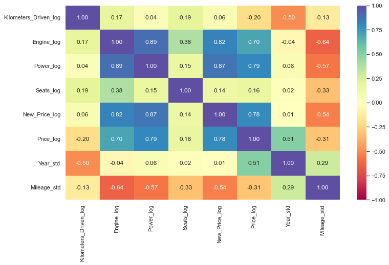

```python
# check the correlations of the log transformed variables
plt.figure(figsize=(12, 7))
sns.heatmap(
    df4[dist_cols].corr(), annot=True, vmin=-1, vmax=1, fmt=".2f", cmap="Spectral"
)
```

We will need to drop the Power_log variable due it its high co-linearity (>.85) with both New_Price_log and Engine_log.

## Part 3: Model Building and Performance Evaluation

We can use a basic model with all null values dropped to use as a baseline to compare our model performance.

```python
# drop the Name column from the base model and drop all null values
df.drop("Name", axis=1, inplace=True)
df.dropna(inplace=True)
```

```python
# define X features and Y target variable
X = df.drop(["Price"], axis=1)
y = df["Price"]
```

```python
# get dummy variables of categorical variables
X = pd.get_dummies(
    X,
    columns=X.select_dtypes(include=["object", "category"]).columns.tolist(),
    drop_first=True,
)
X.columns
```

```
Index(['Year', 'Kilometers_Driven', 'Mileage', 'Engine', 'Power', 'Seats',
       'New_Price', 'Location_Bangalore', 'Location_Chennai',
       'Location_Coimbatore', 'Location_Delhi', 'Location_Hyderabad',
       'Location_Jaipur', 'Location_Kochi', 'Location_Kolkata',
       'Location_Mumbai', 'Location_Pune', 'Fuel_Type_Diesel',
       'Fuel_Type_Electric', 'Fuel_Type_LPG', 'Fuel_Type_Petrol',
       'Transmission_Manual', 'Owner_Type_Fourth & Above', 'Owner_Type_Second',
       'Owner_Type_Third'],
      dtype='object')
```

```python
# splitting the data in 70:30 ratio for train to test data

x_train, x_test, y_train, y_test = train_test_split(
    X, y, test_size=0.3, random_state=101
)
```

```python
# creating an instance of a linear reg model and fitting to the data
lin_reg_model = LinearRegression()
lin_reg_model.fit(x_train, y_train)
```

```
LinearRegression()
```

```python
# function to compute adjusted R-squared
def adj_r2_score(predictors, targets, predictions):
    r2 = r2_score(targets, predictions)
    n = predictors.shape[0]
    k = predictors.shape[1]
    return 1 - ((1 - r2) * (n - 1) / (n - k - 1))


# function to compute MAPE
def mape_score(targets, predictions):
    return np.mean(np.abs(targets - predictions) / targets) * 100


# function to compute different metrics to check performance of a regression model
def model_performance_regression(model, predictors, target):
    """
    Function to compute different metrics to check regression model performance

    model: regressor
    predictors: independent variables
    target: dependent variable
    """

    # predicting using the independent variables
    pred = model.predict(predictors)

    r2 = r2_score(target, pred)  # to compute R-squared
    adjr2 = adj_r2_score(predictors, target, pred)  # to compute adjusted R-squared
    rmse = np.sqrt(mean_squared_error(target, pred))  # to compute RMSE
    mae = mean_absolute_error(target, pred)  # to compute MAE
    mape = mape_score(target, pred)  # to compute MAPE

    # creating a dataframe of metrics
    df_perf = pd.DataFrame(
        {
            "RMSE": rmse,
            "MAE": mae,
            "R-squared": r2,
            "Adj. R-squared": adjr2,
            "MAPE": mape,
        },
        index=[0],
    )

    return df_perf
```

```python
# Checking model performance on train set
print("Training Performance\n")
lin_reg_model_train_perf = model_performance_regression(lin_reg_model, x_train, y_train)
lin_reg_model_train_perf
```

```
Training Performance
```

|  | RMSE | MAE | R-squared | Adj. R-squared | MAPE |
| --- | --- | --- | --- | --- | --- |
| 0 | 5.346762 | 3.087346 | 0.767995 | 0.766575 | 62.905614 |

```python
# Checking model performance on test set
print("Test Performance\n")
lin_reg_model_test_perf = model_performance_regression(lin_reg_model, x_test, y_test)
lin_reg_model_test_perf
```

```
Test Performance
```

|  | RMSE | MAE | R-squared | Adj. R-squared | MAPE |
| --- | --- | --- | --- | --- | --- |
| 0 | 6.004132 | 3.2024 | 0.731411 | 0.727543 | 55.551193 |

Now we will do the same for our model with preprocessed data and feature transformations. We will use Step Forward Feature Selection to define the most influential variables in the model

```python
# define training and test set
df4.drop(["Name"], axis=1, inplace=True)
X = df4.drop(["Price_log", "Power_log"], axis=1)
y = df4["Price_log"]
X = pd.get_dummies(
    X,
    columns=X.select_dtypes(include=["object", "category"]).columns.tolist(),
    drop_first=True,
)
x_train, x_test, y_train, y_test = train_test_split(
    X, y, test_size=0.3, random_state=101
)
```

```python
!pip install mlxtend
```

```python
from mlxtend.feature_selection import SequentialFeatureSelector as SFS

reg = LinearRegression()

# Build step forward feature selection
sfs = SFS(
    reg,
    k_features=x_train.shape[1],  # k_features denotes the number of features to select
    forward=True,
    floating=False,
    scoring="r2",
    n_jobs=-1,  # n_jobs=-1 means all processor cores will be used
    verbose=2,
    cv=5,
)

# Perform SFFS
sfs = sfs.fit(x_train, y_train)
```

[output not shown]

[output cut: 146 more lines]

[output not shown]

```
(0.5, 1.0)
```

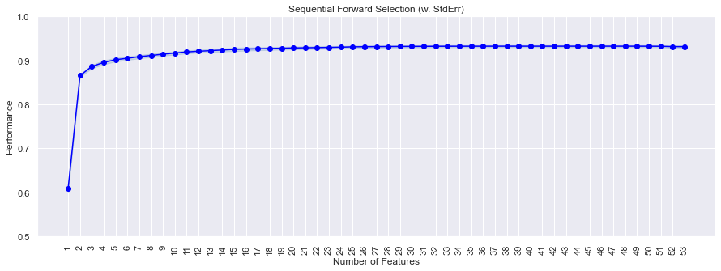

```python
# to plot the performance with addition of each feature
from mlxtend.plotting import plot_sequential_feature_selection as plot_sfs

fig1 = plot_sfs(sfs.get_metric_dict(), kind="std_err", figsize=(15, 5))
plt.title("Sequential Forward Selection (w. StdErr)")
plt.xticks(rotation=90)
plt.ylim(0.5, 1)
```

The performance stagnates around 15 features.

```python
reg = LinearRegression()

# Build step forward feature selection using only 15 features
sfs = SFS(
    reg,
    k_features=15,
    forward=True,
    floating=False,
    scoring="r2",
    n_jobs=-1,
    verbose=2,
    cv=5,
)

# Perform SFFS
sfs = sfs.fit(x_train, y_train)
```

[output not shown]

```python
# let us select the features which are important
feat_cols = list(sfs.k_feature_idx_)
x_train.columns[feat_cols]
```

```
Index(['Kilometers_Driven_log', 'Engine_log', 'New_Price_log', 'Year_std',
       'Location_Bangalore', 'Location_Coimbatore', 'Location_Hyderabad',
       'Location_Kolkata', 'Fuel_Type_Petrol', 'Transmission_Manual',
       'Make_chevrolet', 'Make_mahindra', 'Make_maruti', 'Make_skoda',
       'Make_tata'],
      dtype='object')
```

```python
# filter training data to include only important features
x_train_final = x_train[x_train.columns[feat_cols]]
```

```python
# filter test data for important features
x_test_final = x_test[x_train_final.columns]
```

```python
# train and fit the linear regression model
lin_reg_model2 = LinearRegression()
lin_reg_model2.fit(x_train_final, y_train)
```

```
LinearRegression()
```

```python
# model performance on train set
print("Training Performance\n")
lin_reg_model2_train_perf = model_performance_regression(
    lin_reg_model2, x_train_final, y_train
)
lin_reg_model2_train_perf
```

```
Training Performance
```

|  | RMSE | MAE | R-squared | Adj. R-squared | MAPE |
| --- | --- | --- | --- | --- | --- |
| 0 | 0.238866 | 0.17159 | 0.925493 | 0.925223 | 1.298723 |

```python
# model performance on test set
print("Test Performance\n")
lin_reg_model2_test_perf = model_performance_regression(
    lin_reg_model2, x_test_final, y_test
)
lin_reg_model2_test_perf
```

```
Test Performance
```

|  | RMSE | MAE | R-squared | Adj. R-squared | MAPE |
| --- | --- | --- | --- | --- | --- |
| 0 | 0.230209 | 0.170979 | 0.927498 | 0.926882 | 1.292893 |

Performance measures are similar between training and test data, so our model did not overfit. We have an adjusted R^2 value of around 93%.

```python
# compare the two models - training performance comparison

models_train_comp_df = pd.concat(
    [lin_reg_model_train_perf.T, lin_reg_model2_train_perf.T], axis=1,
)

models_train_comp_df.columns = [
    "Linear Regression base",
    "Linear Regression sklearn (SFS features)",
]

print("Training performance comparison:")
models_train_comp_df
```

```
Training performance comparison:
```

|  | Linear Regression base | Linear Regression sklearn (SFS features) |
| --- | --- | --- |
| RMSE | 5.346762 | 0.238866 |
| MAE | 3.087346 | 0.171590 |
| R-squared | 0.767995 | 0.925493 |
| Adj. R-squared | 0.766575 | 0.925223 |
| MAPE | 62.905614 | 1.298723 |

```python
# compare the two models - test performance comparison

models_test_comp_df = pd.concat(
    [lin_reg_model_test_perf.T, lin_reg_model2_test_perf.T], axis=1,
)

models_test_comp_df.columns = [
    "Linear Regression base",
    "Linear Regression sklearn (SFS features)",
]

print("Test performance comparison:")
models_test_comp_df
```

```
Test performance comparison:
```

|  | Linear Regression base | Linear Regression sklearn (SFS features) |
| --- | --- | --- |
| RMSE | 6.004132 | 0.230209 |
| MAE | 3.202400 | 0.170979 |
| R-squared | 0.731411 | 0.927498 |
| Adj. R-squared | 0.727543 | 0.926882 |
| MAPE | 55.551193 | 1.292893 |

```python
# fit a regressional model with polynomial features
from sklearn.preprocessing import PolynomialFeatures
from sklearn import linear_model

poly = PolynomialFeatures(degree=2, interaction_only=True)
x_train2 = poly.fit_transform(x_train)
x_test2 = poly.fit_transform(x_test)

poly_clf = linear_model.LinearRegression()

poly_clf.fit(x_train2, y_train)

y_pred = poly_clf.predict(x_test2)

# In sample (training) R^2 will always improve with the number of variables
print(poly_clf.score(x_train2, y_train))
# test R^2 is our measure of sucess
print(poly_clf.score(x_test2, y_test))
print(x_train.shape)
print(x_train2.shape)
```

```
0.9659178580035824
-1404442436972765.8
(4159, 53)
(4159, 1432)
```

The regression model with polynomial features overfits to the training data and performs poorly on test data. This is not a good model to use. It also requires a lot more features. Our model with an adjusted R^2 value of 0.93 would be the recommended model for the business to use.

## Part 4: Conclusions and Recommendations

## Summary/Insights

**Data Background:**

- There are 7253 rows and 14 columns in the data.
- The Mileage, Engine, Power, Seats, and Price columns have null values.
- The dependent variable, Price, is of float type.
- The other numeric columns are S. No., Year, Kilometers_Driven, Seats, and New_Price.
- All other columns are of object datatype.

**Data Preprocessing:**

- The S.No. column was dropped as it isn’t important to the analysis.
- The missing values in the target variable were dropped.
- Mileage, Engine, and Power were converted to numeric datatypes after dropping the units.
- Fuel, Transmission, and Owner_type were converted to category datatypes.
- The Make column was created by extracting the make from the Name column.
- Outliers in the Price column were dropped after plotting the boxplot and comparing the New_Price with the used car price.
- Outliers in the Kilometers_Driven column were defined by the values greater than 4*IQR from the median. These outliers were dropped.
- Outliers in Mileage column were defined by the 0 values. These were replaced based on the average mileage by vehicle make.
- Outliers in the Power and Engine column were defined by comparing the values in the two columns since they are highly correlated. The outliers were replaced by Google search of the true value.
- Outliers in the Seats column were defined by the 0 values. This was replaced via a Google search.
- The car with the highest New_Price was dropped from the data as it was an outlier compared to the rest of the data.
- Missing values in columns Mileage, Engine, Power, and Seats were imputed based on other cars with the same Name.
- The remaining missing data in the Mileage column was imputed based on the average mileage by vehicle make or dropped.
- Remaining missing data in the Power column was imputed based on the median power in the Engine column.
- Remaining missing values were dropped.
- Name column was dropped.
- Log transformations were done on the Kilometers_Driven, Engine, Power, New_Price, and Price (in rupees) columns since the data was right-skewed.
- Standard scaling was done on the Year and Mileage columns.
- Power variable was dropped from the analysis due to its co-linearity with other variables.
- Dummy variables were obtained for the categorical variables.

**Observations from EDA:**

- The Price, Kilometers_Driven, Engine, Power, and New_Price variables are skewed to the right.
- The Year variable is skewed to the left.
- The Mileage variable is approximately normally distributed.
- Most cars have 5 seats, are located in Mumbai, have diesel fuel type, manual transmission, first ownership, and Maruti make.
- The Price column is highly correlated with New_Price, Power, and Engine columns
- Power and New_Price are highly correlated.
- Power and Engine columns are highly correlated with each other.
- Car manufactured more recently sell for higher.
- The median price is lowest for Jaipur, Pune, and Kolkata.
- CNG and LPG are the least expensive cars.
- Cars with one owner are more expensive than those which have had two or more owners.
- Automatic cars are priced higher than manual cars.
- Cars with 9 or 10 seats have the lowest median price.
- Porsche and Land Rover have the highest median prices, while Chevrolet and Ambassador have the lowest median prices of used cars.

**Model Building and Performance:**

The pre-processed model without polynomial features performed the best with only 15 features chosen as part of step-forward feature selection. The chosen model performed similarly on the training and test data.

## Recommendations

- The price of a used car is highly correlated with the new price, power, and engine of a car, though these variables are also correlated with each other
- The most important features in building a linear regression model of the data are:

  ```
   'Kilometers_Driven_log', 'Engine_log', 'New_Price_log', 'Year_std',
   'Location_Bangalore', 'Location_Coimbatore', 'Location_Hyderabad',
   'Location_Kolkata', 'Fuel_Type_Petrol', 'Transmission_Manual',
   'Make_chevrolet', 'Make_mahindra', 'Make_maruti', 'Make_skoda',
   'Make_tata'
  ```

- A linear regression model was successfully built that can be used by Cars4U to predict the log(price) of a used car with an adjusted R^2 of around 0.93 and RMSE of 0.23. 93% of the variance in the price is explained by the regression model. The RMSE is a measure of regression fit.
- It is recommended that the business gather more data on other features like the type of car, its current condition, or accident history to see how these may influence performance.
- Some categories like electric vehicles, or cars with three or more owners are a very small part of the data. It is recommended to gather more data from these categories to better predict the price of cars in these categories.